# R语言-拍拍贷数据探索性分析

# 1.数据说明

【数据用途】 所提供数据为拍拍贷真实业务数据，但仅为信用标的一个样本，仅供数据分析和学术研究目的使用，而非信息披 露。从这个数据中推导得到的结果不反映拍拍贷平台的 整体情况，也不代表拍拍贷官方的态度。

【数据描述】 所提供数据包含了成交时间从2015年1月1日到2017年1月30日的328553支信用标。

# 2.数据概览

```
## 'data.frame':    328553 obs. of  21 variables:
##  $ ListingId       : int  126541 133291 142421 149711 152141 162641 171191 175451 182261 193831 ...
##  $ 借款金额        : int  18000 9453 27000 25000 20000 20000 3940 20000 25000 10475 ...
##  $ 借款期限        : int  12 12 24 12 6 12 6 12 12 6 ...
##  $ 借款利率        : num  18 20 20 18 16 14 18 18 16 18 ...
##  $ 借款成功日期    : Factor w/ 756 levels "2015-01-01","2015-01-02",..: 119 70 477 84 22 79 172 439 75 100 ...
##  $ 初始评级        : Factor w/ 6 levels "A","B","C","D",..: 3 4 5 3 3 1 5 2 2 3 ...
##  $ 借款类型        : Factor w/ 4 levels "APP闪电","电商",..: 4 4 3 4 2 3 2 3 4 2 ...
##  $ 是否首标        : Factor w/ 2 levels "否","是": 1 1 1 1 1 1 1 1 1 1 ...
##  $ 年龄            : int  35 34 41 34 24 36 27 32 33 25 ...
##  $ 性别            : Factor w/ 2 levels "男","女": 1 1 1 1 1 1 2 1 2 1 ...
##  $ 手机认证        : Factor w/ 2 levels "成功认证","未成功认证": 1 2 1 1 1 1 1 1 1 1 ...
##  $ 户口认证        : Factor w/ 2 levels "成功认证","未成功认证": 2 1 2 1 1 1 1 1 2 1 ...
##  $ 视频认证        : Factor w/ 2 levels "成功认证","未成功认证": 1 2 2 1 1 1 1 1 1 1 ...
##  $ 学历认证        : Factor w/ 2 levels "成功认证","未成功认证": 2 2 2 2 2 2 2 2 2 2 ...
##  $ 征信认证        : Factor w/ 2 levels "成功认证","未成功认证": 2 2 2 2 2 2 2 2 2 2 ...
##  $ 淘宝认证        : Factor w/ 2 levels "成功认证","未成功认证": 2 2 2 2 2 2 2 2 2 2 ...
##  $ 历史成功借款次数: int  11 4 5 6 13 7 15 7 7 9 ...
##  $ 历史成功借款金额: num  40326 14500 21894 36190 77945 ...
##  $ 总待还本金      : num  8713 7891 11726 9703 0 ...
##  $ 历史正常还款期数: int  57 13 25 41 118 56 75 52 41 49 ...
##  $ 历史逾期还款期数: int  16 1 3 1 14 0 8 0 2 4 ...
```

### 描述性统计

```
##    ListingId           借款金额         借款期限        借款利率
##  Min.   :  126541   Min.   :   100   Min.   : 1.00   Min.   : 6.5
##  1st Qu.:11908871   1st Qu.:  2033   1st Qu.: 6.00   1st Qu.:20.0
##  Median :19523251   Median :  3397   Median :12.00   Median :20.0
##  Mean   :19079479   Mean   :  4424   Mean   :10.21   Mean   :20.6
##  3rd Qu.:26298621   3rd Qu.:  5230   3rd Qu.:12.00   3rd Qu.:22.0
##  Max.   :32819531   Max.   :500000   Max.   :24.00   Max.   :24.0
##
##      借款成功日期    初始评级      借款类型      是否首标
##  2017-01-25:  3558   A: 10284   APP闪电:112079   否:241090
##  2017-01-20:  3063   B: 33188   电商   :  1069   是: 87463
##  2016-12-14:  2266   C:131705   普通   :118103
##  2016-12-02:  2033   D:134860   其他   : 97302
##  2017-01-09:  1859   E: 17027
##  2017-01-04:  1806   F:  1489
##  (Other)   :313968
##       年龄       性别              手机认证            户口认证
##  Min.   :17.00   男:221946   成功认证  :123007   成功认证  : 10105
##  1st Qu.:24.00   女:106607   未成功认证:205546   未成功认证:318448
##  Median :28.00
##  Mean   :29.14
##  3rd Qu.:33.00
##  Max.   :56.00
##
##        视频认证            学历认证            征信认证
##  成功认证  : 18501   成功认证  :114124   成功认证  :  9606
##  未成功认证:310052   未成功认证:214429   未成功认证:318947
##
##
##
##
##
##        淘宝认证      历史成功借款次数  历史成功借款金额    总待还本金
##  成功认证  :  1152   Min.   :  0.000   Min.   :      0   Min.   :      0
##  未成功认证:327401   1st Qu.:  0.000   1st Qu.:      0   1st Qu.:      0
##                      Median :  2.000   Median :   5000   Median :   2542
##                      Mean   :  2.323   Mean   :   8786   Mean   :   3722
##                      3rd Qu.:  3.000   3rd Qu.:  10355   3rd Qu.:   5447
##                      Max.   :649.000   Max.   :7405926   Max.   :1172653
##
##  历史正常还款期数   历史逾期还款期数
##  Min.   :   0.000   Min.   : 0.0000
##  1st Qu.:   0.000   1st Qu.: 0.0000
##  Median :   5.000   Median : 0.0000
##  Mean   :   9.948   Mean   : 0.4233
##  3rd Qu.:  13.000   3rd Qu.: 0.0000
##  Max.   :2507.000   Max.   :60.0000
##
```

结论：一共有328553个对象，21个变量

# 3.字段说明

1.ListingId：列表序号，为列表的唯一键。

2.借款金额：列表成交总金额。

3.借款期限：总的期数（按月计）。

4.借款利率：年化利率（百分数）。

5.款成功日期：列表成交的日期。都在2015年1月1日以后。

6 .始评级：列表成交时的信用评级。AAA为安全标，AA为赔标，A-F为信用等级。

7.借款类型：分为’应收安全标’，‘电商’，‘APP闪电’，‘普通’和‘其他’。

8.是否首标：该标是否为借款人首标。

9.年龄：借款人在该列表借款成功时的年龄。

10.性别：该列表借款人性别。

11.手机认证：该列表借款人手机实名认证是否成功。

12.户口认证：该列表借款人户口认证是否成功。

13.视频认证：该列表借款人视频认证是否成功。

14.学历认证：该列表借款人学历认证是否成功。成功则表示有大专及以上学历。

15.征信认证：该列表借款人征信认证是否成功。成功则表示有人行征信报告。

16.淘宝认证：该列表借款人淘宝认证是否成功。成功则表示为淘宝店主。

17.历史成功借款次数：借款人在该列表成交之前的借款成功次数。

18.历史成功借款金额：借款人在该列表成交之前的借款成功金额。

19.总待还本金：借款人在该列表成交之前待还本金金额。

20.历史正常还款期数：借款人在该列表成交之前的按期还款期数。

21.历史逾期还款期数：借款人在该列表成交之前的逾期还款期数。

# 4.单变量分析

### 4.1.借款金额

```
##    Min. 1st Qu.  Median    Mean 3rd Qu.    Max.
##     100    2033    3397    4424    5230  500000
```

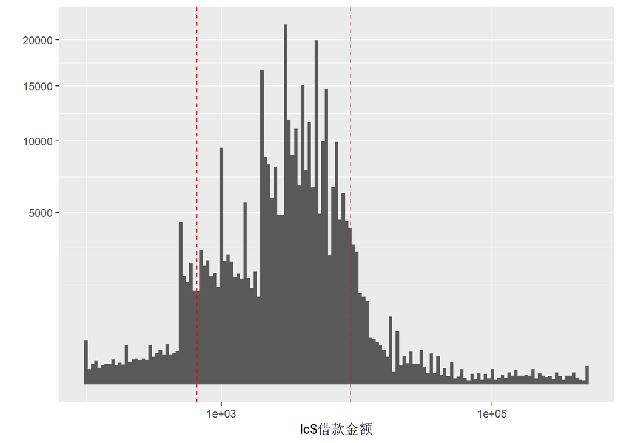

```
##  5%
## 660
```

```
##  95%
## 9000
```

结论：有一些金额分组有着较高的频次。5%分位数到95%分位数的金额为660~9000，大部分为小额贷款。

### 4.2.借款期限

```
##    Min. 1st Qu.  Median    Mean 3rd Qu.    Max.
##    1.00    6.00   12.00   10.21   12.00   24.00
```

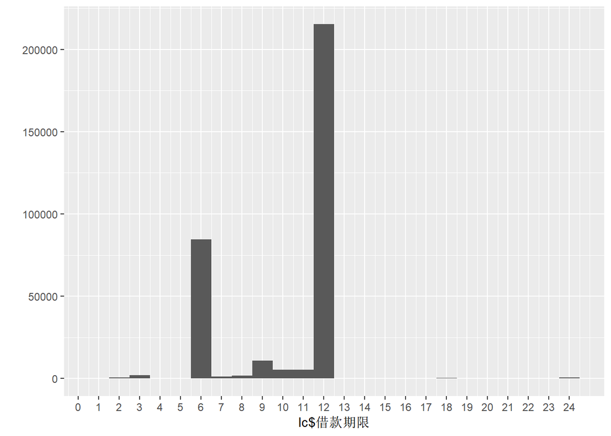

```
##
##      1      2      3      4      5      6      7      8      9     10
##     42    802   1993     94     85  84486   1239   1852  10769   5472
##     11     12     15     17     18     20     21     24
##   5351 215330     31      1    367      1      2    636
```

结论：借款期限最多的月份是6月和12月。

### 4.3.借款利率

```
##    Min. 1st Qu.  Median    Mean 3rd Qu.    Max.
##     6.5    20.0    20.0    20.6    22.0    24.0
```

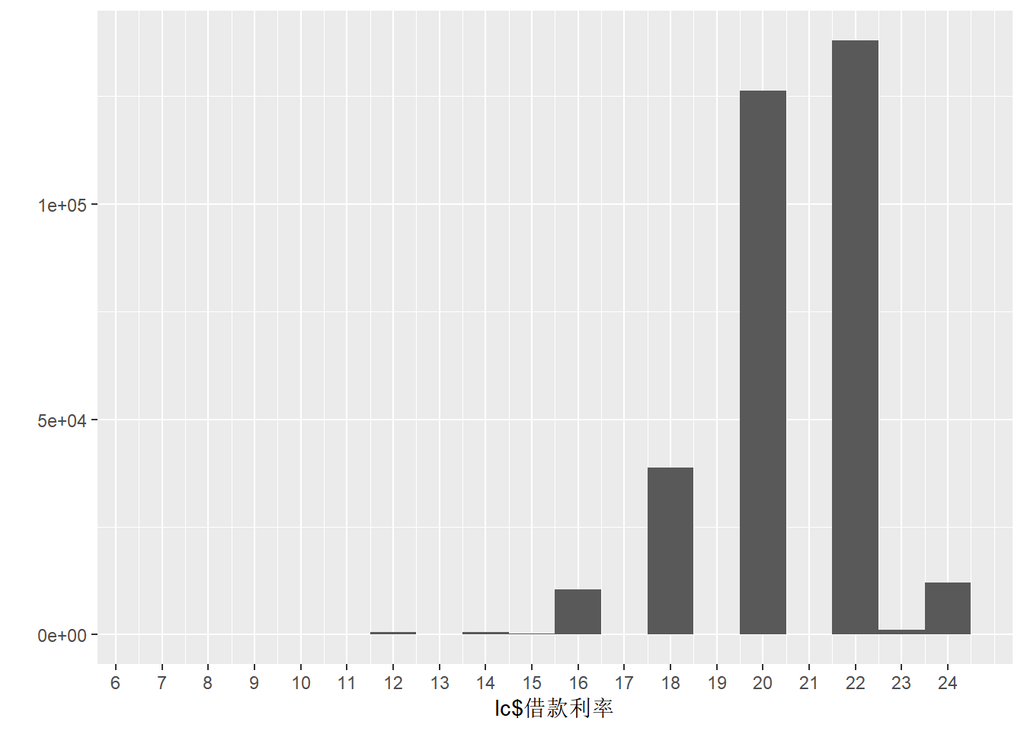

结论：借款利率最多的为20%和22%

### 4.4.借款日期

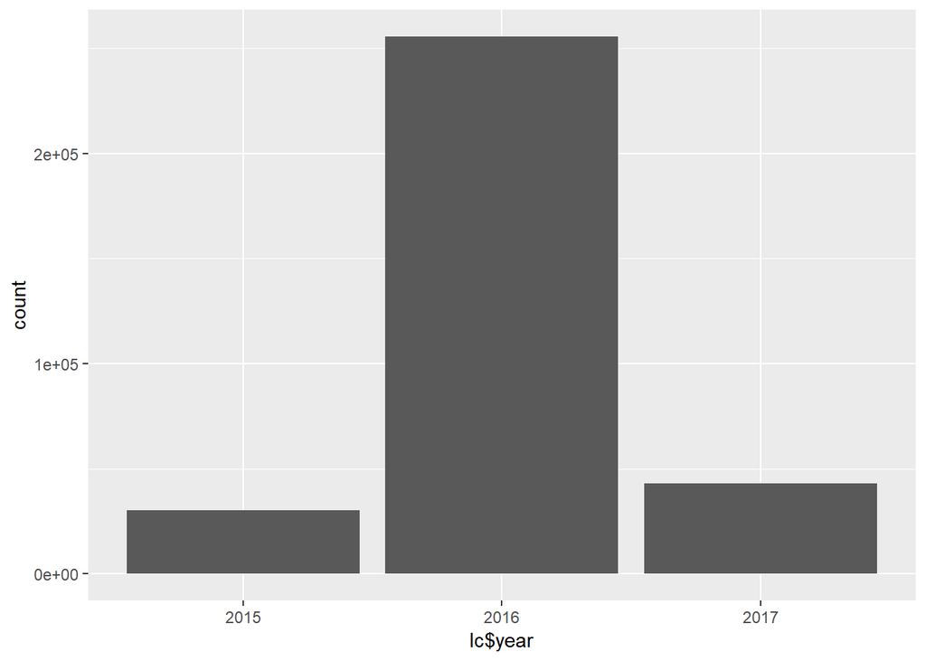

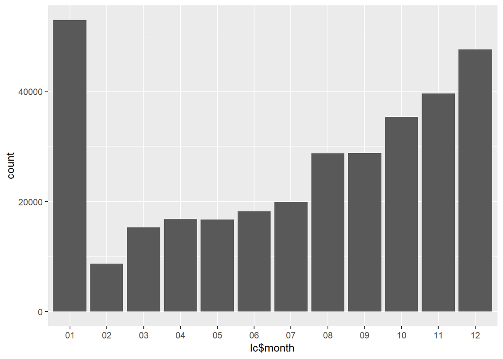

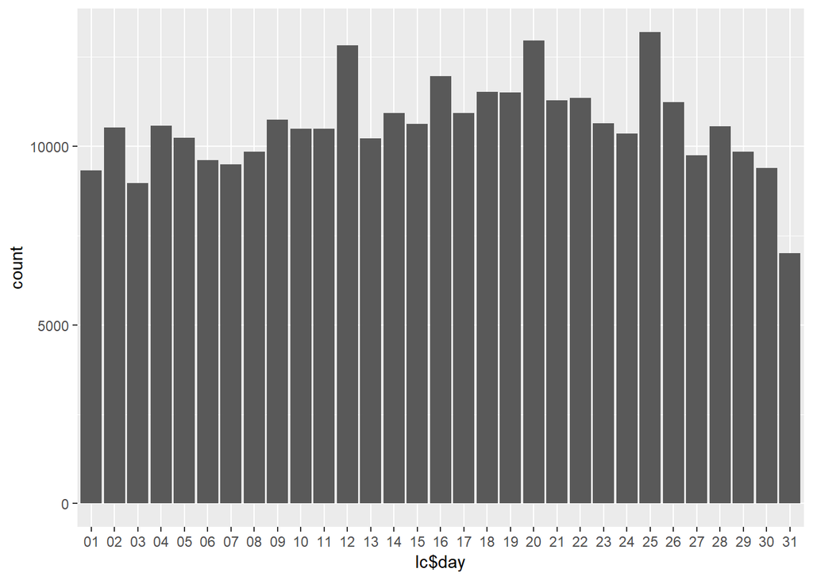

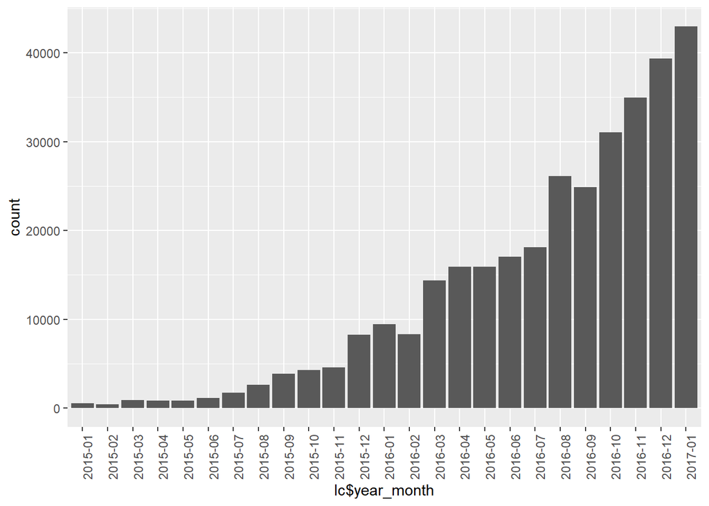

结论：数据集的借款日期是从2015年1月到2017年1月，主要是2016年借款的数据，借款成功数量整体上呈现出随时间而增加的趋势。

### 4.5.初始评级

```
##      A      B      C      D      E      F
##  10284  33188 131705 134860  17027   1489
```

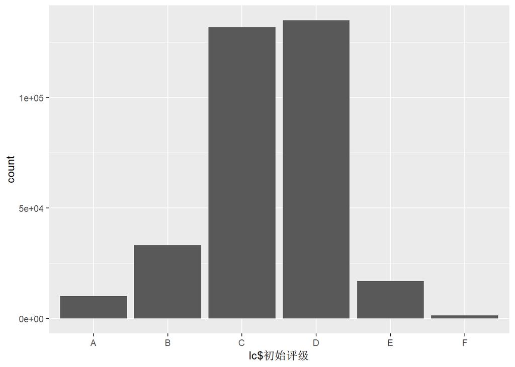

结论：初始评级大多为C和D。

### 4.6.借款类型

```
## APP闪电    电商    普通    其他
##  112079    1069  118103   97302
```

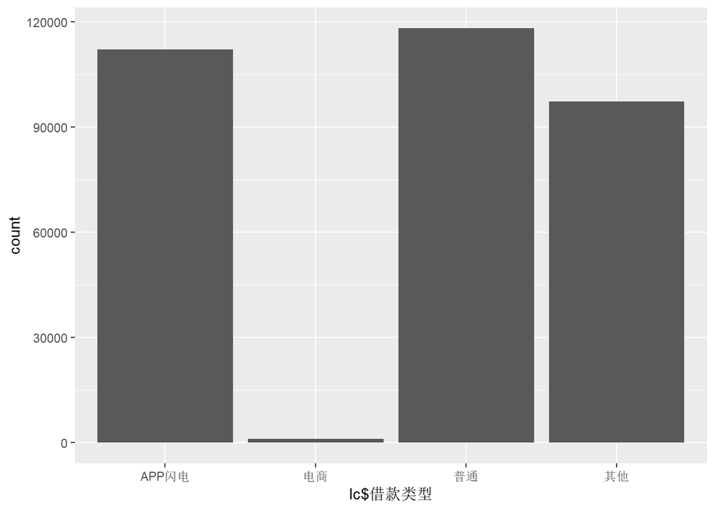

结论：借款类型主要是APP闪电、普通和其他，电商类型最少。

### 4.7.是否首标

```
##     否     是
## 241090  87463
```

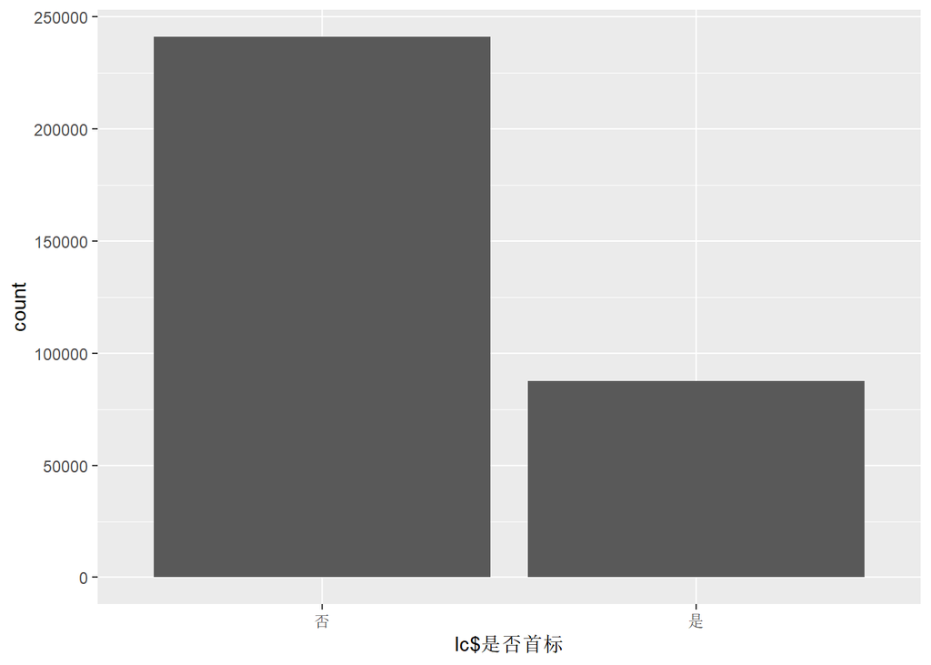

结论：非首标的数量占多数，超过首标的两倍。

### 4.8.年龄

```
##    Min. 1st Qu.  Median    Mean 3rd Qu.    Max.
##   17.00   24.00   28.00   29.14   33.00   56.00
```

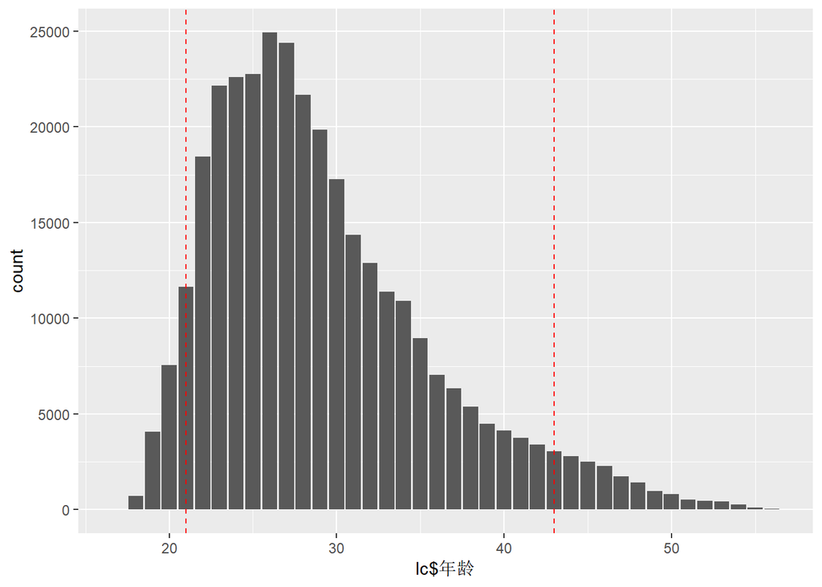

```
## 5%
## 21
```

```
## 95%
##  43
```

结论：借款人年龄分布呈右偏分布。5%分位数到95%分位数的年龄为21~43岁，大部分为中青年。

### 4.9.性别

```
##     男     女
## 221946 106607
```

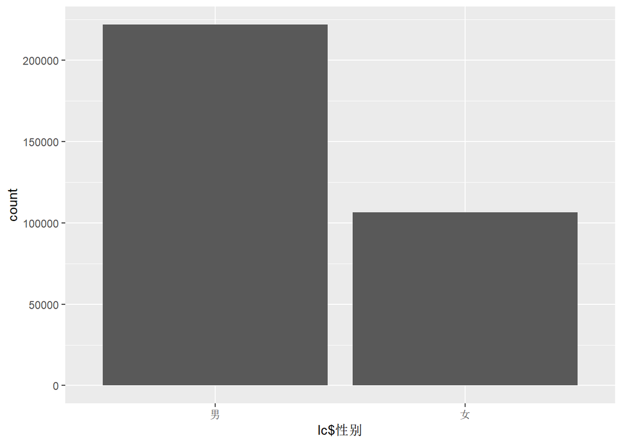

结论：借款人多为男性，数量约为女性借款人数的二倍。

### 4.10.认证方式

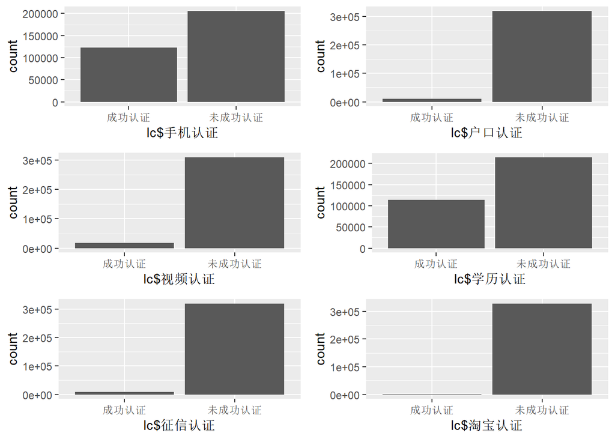

结论：大多数是通过手机认证和学历认证成功的。

### 4.11.历史成功借款次数

```
##    Min. 1st Qu.  Median    Mean 3rd Qu.    Max.
##   0.000   0.000   2.000   2.323   3.000 649.000
```

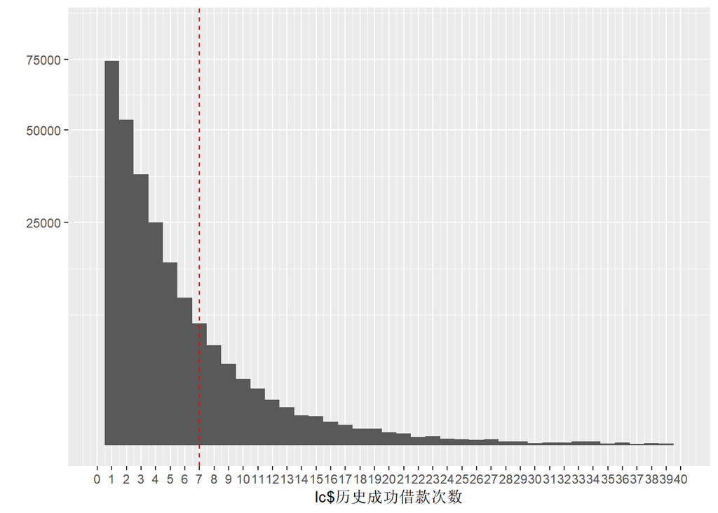

结论：95%借款次数在七次以下。

### 4.12.历史逾期还款期数

```
##    Min. 1st Qu.  Median    Mean 3rd Qu.    Max.
##  0.0000  0.0000  0.0000  0.4233  0.0000 60.0000
```

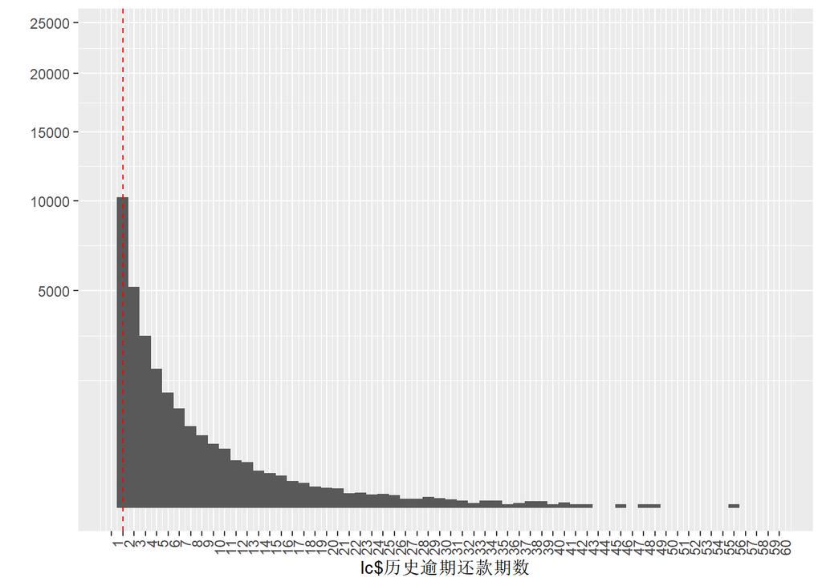

结论：95%历史逾期还款期数都在2次以下。

## 单变量分析总结

### 数据结构

所分析数据集一共有328553条数据，包含21个变量。

### 作图观察

1.有一些金额分组有着较高的频次。5%分位数到95%分位数的金额为660~9000，大部分为小额贷款。

2.借款期限最多的月份是6月和12月。

3.借款利率最多的为20%和22%

4.数据集的借款日期是从2015年1月到2017年1月，主要是2016年借款的数据，借款成功数量整体上呈现出随时间而增加的趋势。

5.初始评级大多为C和D。

6.借款类型主要是APP闪电、普通和其他，电商类型最少。

7.非首标的数量占多数，超过首标的两倍。

8.借款人年龄分布呈右偏分布。5%分位数到95%分位数的年龄为21~43岁，大部分为中青年。

9.借款人多为男性，数量约为女性借款人数的二倍。

10.大多数是通过手机认证和学历认证成功的。

11.95%借款次数在七次以下。

12.95%历史逾期还款期数都在2次以下。

### 讨论

数据集的所有变量中，更希望了解借款利率这一个变量及其影响因素。因此下面我们试图分析各个变量和借款利率之间的关系。

# 5.双变量分析

### 5.0. 借款金额和借款利率的关系

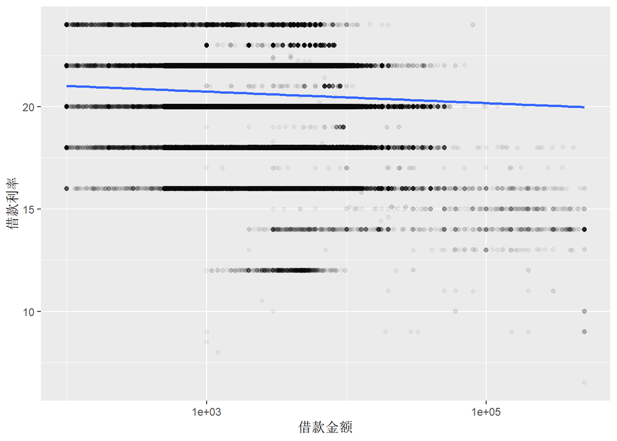

```
##
##  Pearson's product-moment correlation
##
## data:  lc$借款金额 and lc$借款利率
## t = -85.92, df = 328550, p-value < 2.2e-16
## alternative hypothesis: true correlation is not equal to 0
## 95 percent confidence interval:
##  -0.1515827 -0.1448942
## sample estimates:
##        cor
## -0.1482401
```

结论：借款利率随着借款金额的增加而减少,但相关性不是很强。

### 5.1. 借款期限和借款利率的关系

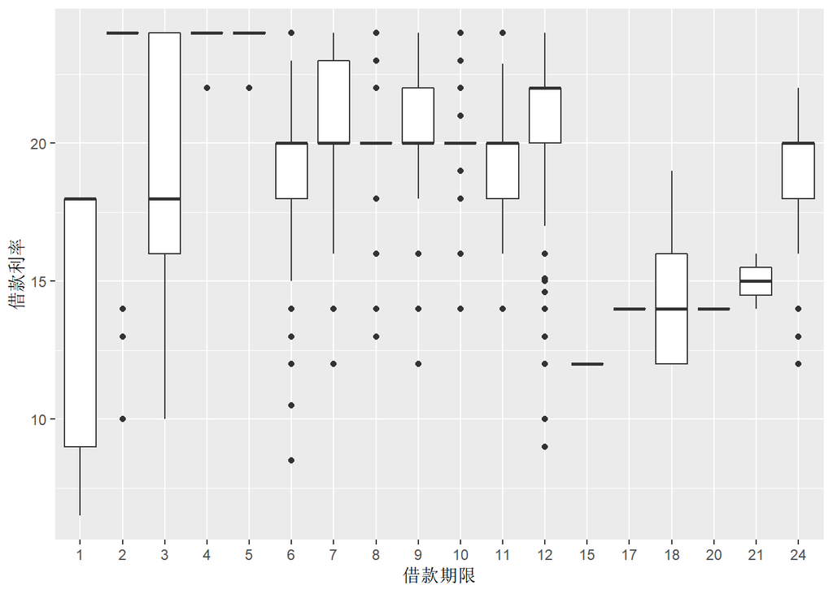

### 5.2. 借款月份和借款利率的关系

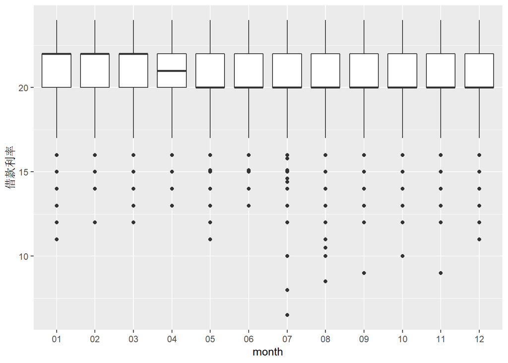

结论：不同月份利率的Q1和Q3基本相同，中位数不同。月份与利率之间五明显关系。

### 5.3. 借款类型和借款利率的关系

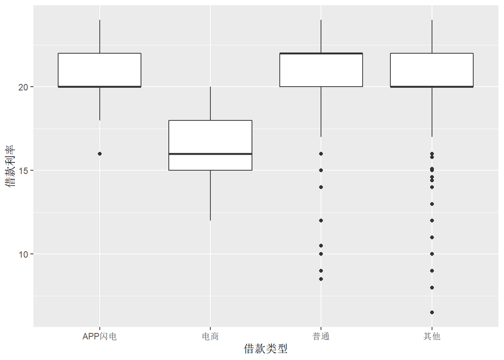

结论：电商的借款利率和其他借款类型相比较低。

### 5.4. 初始评级和借款利率的关系

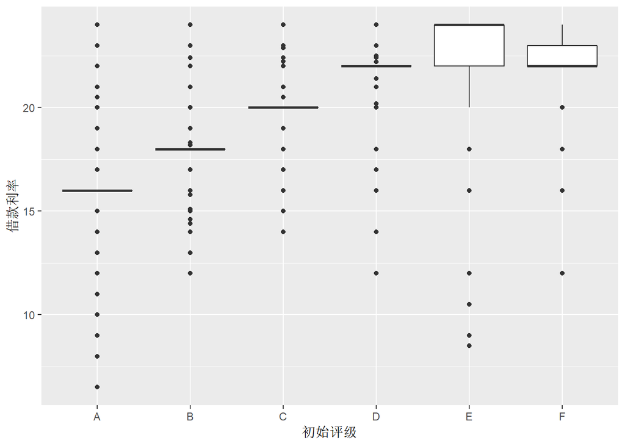

结论：初始评级越低，借款利率越高。

### 5.5. 是否首标和借款利率的关系

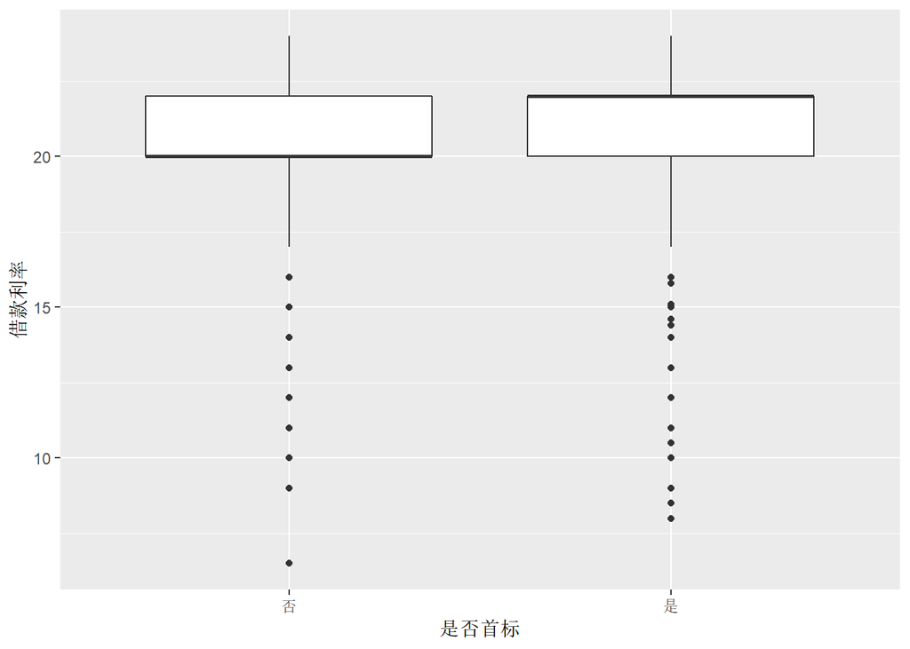

结论：是否首标和借款利率无明显关系。

### 5.6. 年龄和借款利率的关系

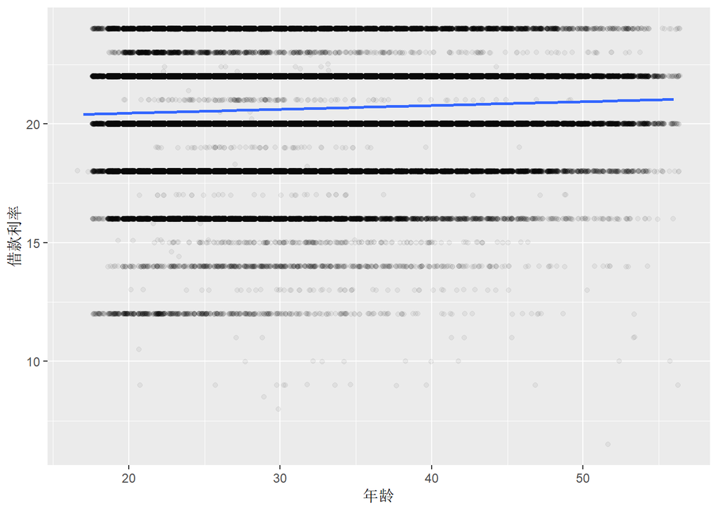

结论：年龄和借款利率无明显关系。

### 5.6. 性别和借款利率的关系

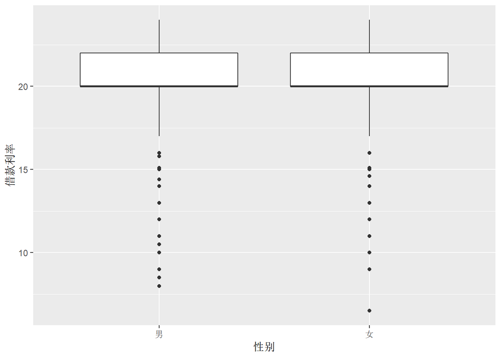

结论：性别和借款利率无明显关系。

### 5.7. 历史成功借款次数和借款利率的关系

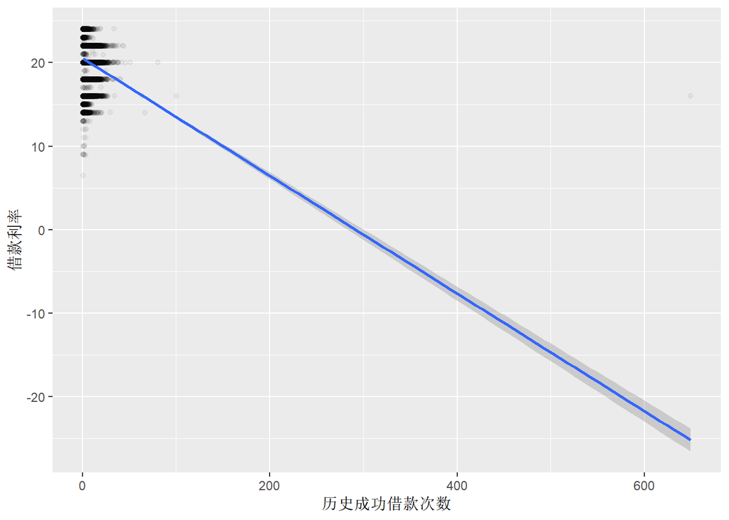

```
##
##  Pearson's product-moment correlation
##
## data:  lc_notfirst$历史成功借款次数 and lc_notfirst$借款利率
## t = -64.774, df = 241090, p-value < 2.2e-16
## alternative hypothesis: true correlation is not equal to 0
## 95 percent confidence interval:
##  -0.1347081 -0.1268612
## sample estimates:
##        cor
## -0.1307867
```

结论：首标时历史成功还款次数为0，各种借款利率都存在。非首标的数据，历史成功借款次数与借款利率呈负相关，历史成功借款次数越高，借款利率越低，但是相关性不是很强。

### 5.8. 历史成功借款金额和借款利率的关系

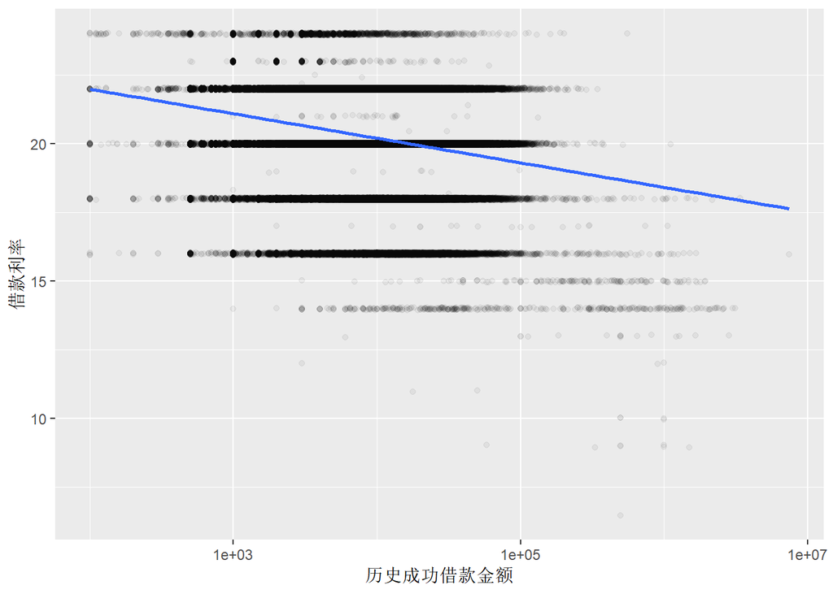

```
##
##  Pearson's product-moment correlation
##
## data:  lc_notfirst$历史成功借款金额 and lc_notfirst$借款利率
## t = -73.511, df = 241090, p-value < 2.2e-16
## alternative hypothesis: true correlation is not equal to 0
## 95 percent confidence interval:
##  -0.1519671 -0.1441587
## sample estimates:
##        cor
## -0.1480652
```

结论：首标时历史成功借款金额为0，各种借款利率都存在。非首标的数据，历史成功借款金额与借款利率呈负相关，历史成功借款金额越高，借款利率越低，但是相关性不是很强。

### 5.9. 历史正常还款期数和借款利率的关系

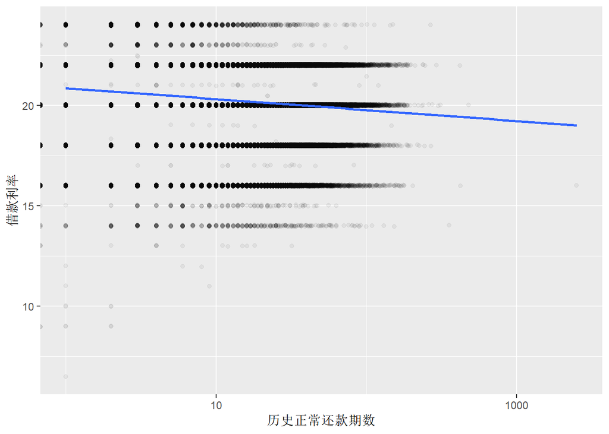

```
##
##  Pearson's product-moment correlation
##
## data:  lc_notfirst$历史正常还款期数 and lc_notfirst$借款利率
## t = -54.675, df = 241090, p-value < 2.2e-16
## alternative hypothesis: true correlation is not equal to 0
## 95 percent confidence interval:
##  -0.1146092 -0.1067236
## sample estimates:
##        cor
## -0.1106681
```

结论：首标时历史正常还款期数大多是0，各种借款利率都存在。非首标的数据，历史正常还款期数与借款利率呈负相关，历史正常还款期数越高，借款利率越低，但是相关性不是很强。

### 5.9. 历史逾期还款期数和借款利率的关系

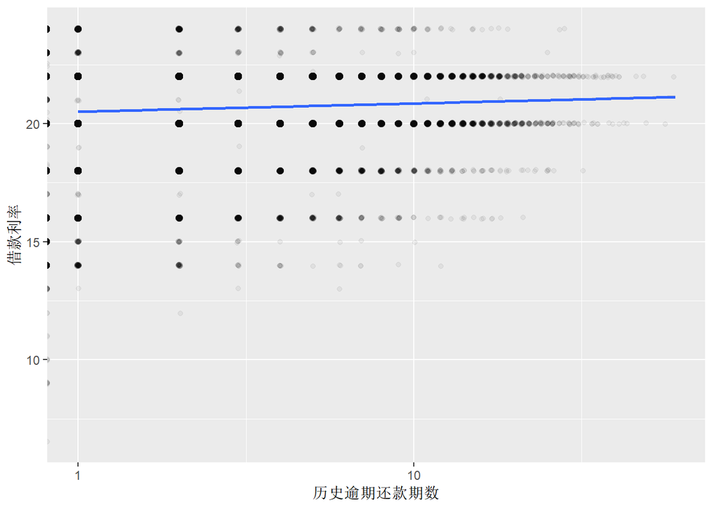

```
##
##  Pearson's product-moment correlation
##
## data:  lc_notfirst$历史逾期还款期数 and lc_notfirst$借款利率
## t = 36.672, df = 241090, p-value < 2.2e-16
## alternative hypothesis: true correlation is not equal to 0
## 95 percent confidence interval:
##  0.07050843 0.07844756
## sample estimates:
##        cor
## 0.07447918
```

结论：首标时历史逾期还款期数都是是0，各种借款利率都存在。非首标的数据，历史成功逾期期数与借款利率没有明显的关系。

## 双变量分析总结

### 图形观察结论

1.借款利率随着借款金额的增加而减少,但相关性不是很强。

2.电商的借款利率和其他借款类型相比较低。

3.初始评级越低，借款利率越高。

4.首标时历史成功还款次数为0，各种借款利率都存在。非首标的数据，历史成功借款次数与借款利率呈负相关，历史成功借款次数越高，借款利率越低，但是相关性不是很强

5.首标时历史成功借款金额为0，各种借款利率都存在。非首标的数据，历史成功借款金额与借款利率呈负相关，历史成功借款金额越高，借款利率越低，但是相关性不是很强。

6.首标时历史正常还款期数大多是0，各种借款利率都存在。非首标的数据，历史正常还款期数与借款利率呈负相关，历史正常还款期数越高，借款利率越低，但是相关性不是很强。

### 总结

我们可以知道借款利率与借款金额，借款类型和初级评级有关，而其中的非首标数据，借款利率还与历史成功借款次数，历史成功借款金额和历史正常还款期数有关。

# 6.多变量分析

### 6.0. 借款金额和借款利率与借款类型的关系

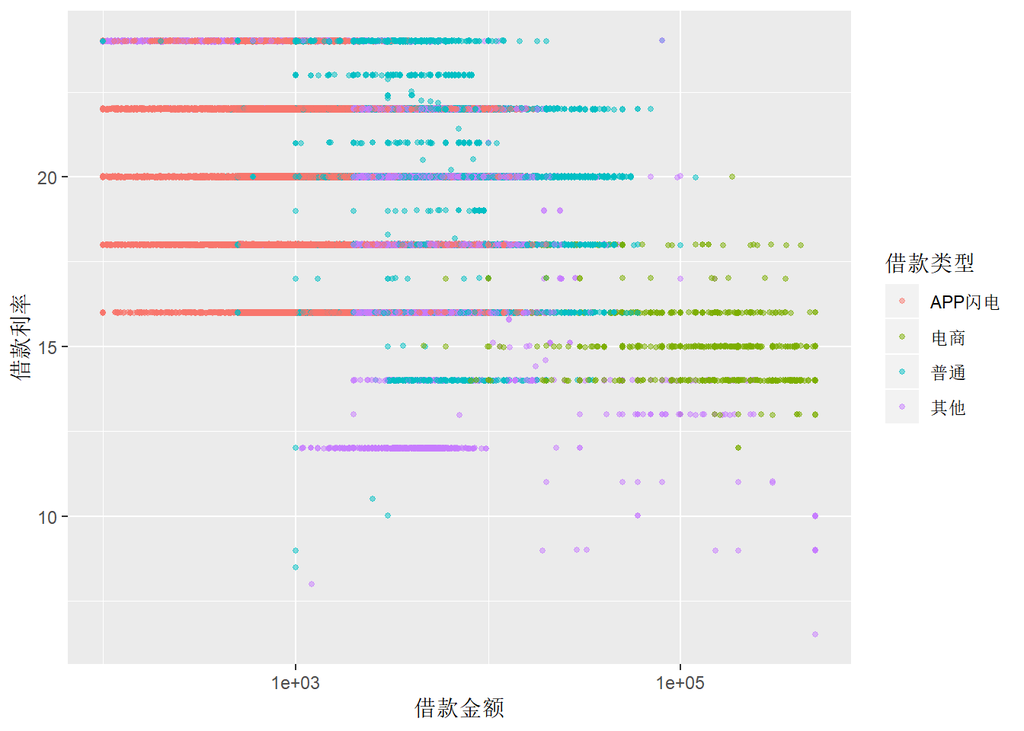

### 6.1. 借款金额和借款利率与初始评级的关系

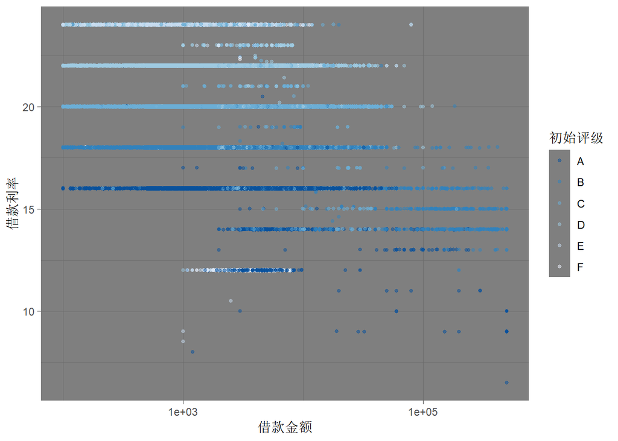

结论：初始评级越高，借款利率越低。贷款金额越高，借款利率越低。

### 6.3. 非首标历史成功借款次数和借款利率与借款类型的关系

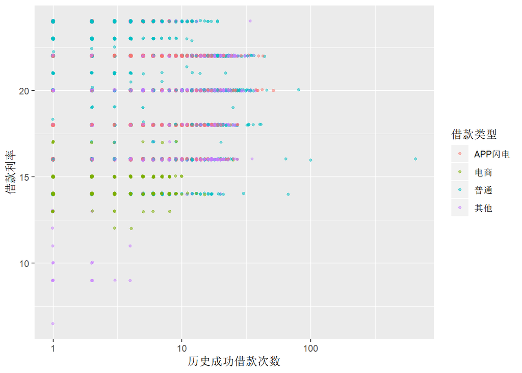

结论：电商的成功借款次数较低，借款利率也偏低；普通的借款利率较高；APP闪电和其他历史成功借款次数较高。

### 6.4. 非首标历史成功借款次数和借款利率与初始评级的关系

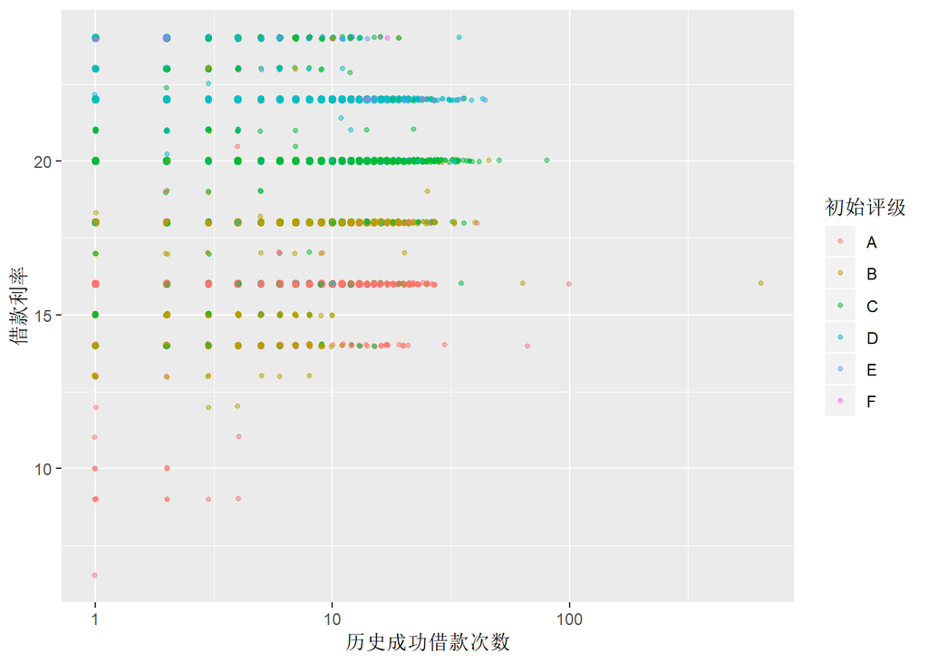

结论：初始评级与历史成功借款次数无明显关系；初始评级越高，借款利率越低。